# Assignment 1

Ishanthi Cooray(30110207)

2024-02-20

# PART 1

```r
libraries <- c("tm", "tidytext", "ggplot2", "wordcloud", "syuzhet", "dplyr", "tibble", "textstem", "textdata", "tidyr","Matrix", "topicmodels", "stringr", "reshape2", "LDAvis", "jsonlite","reticulate","NMF","stm","caret","ggbeeswarm","xfun")

#install.packages(libraries) #Comment out after first execution

for (lib in libraries) {
  library(lib, character.only=TRUE) #Library takes function names without quotes, character only must be used in a loop of this kind.
}
```

#Load the data set

```r
filepath <-"C:\\Users\\ish17\\OneDrive\\Desktop\\data mining\\assignmnt 1\\MS4S09_CW_Book_Reviews.csv" # Define file path. Windows requires \ to be replaced by \\.
df <- as_tibble(read.csv(filepath, stringsAsFactors = FALSE)) # Since we have text data we do not want this read as a factor

# Inspect summary and first few rows of data
print(summary(df))
```

```
##     Title             Book_Price     Reviewer_id            Rating
##  Length:59296       Min.   :  1.00   Length:59296       Min.   :1.000
##  Class :character   1st Qu.: 10.36   Class :character   1st Qu.:4.000
##  Mode  :character   Median : 14.15   Mode  :character   Median :5.000
##                     Mean   : 20.81                      Mean   :4.231
##                     3rd Qu.: 22.99                      3rd Qu.:5.000
##                     Max.   :995.00                      Max.   :5.000
##       Time           Review_title       Review_text        Found_helpful_ratio
##  Min.   :8.688e+08   Length:59296       Length:59296       Min.   :0.0000
##  1st Qu.:1.087e+09   Class :character   Class :character   1st Qu.:0.0000
##  Median :1.169e+09   Mode  :character   Mode  :character   Median :0.6667
##  Mean   :1.173e+09                                         Mean   :0.5491
##  3rd Qu.:1.279e+09                                         3rd Qu.:1.0000
##  Max.   :1.362e+09                                         Max.   :1.0000
##   Publisher         First_author          Genre
##  Length:59296       Length:59296       Length:59296
##  Class :character   Class :character   Class :character
##  Mode  :character   Mode  :character   Mode  :character
##
##
##
```

```r
print(head(df))
```

```
## # A tibble: 6 × 11
##   Title            Book_Price Reviewer_id Rating   Time Review_title Review_text
##   <chr>                 <dbl> <chr>        <int>  <int> <chr>        <chr>
## 1 In Six Days: Wh…      10.2  APD7XINUVG…      4 9.99e8 Solid testi… "Working f…
## 2 Lord Jim              15.6  AITANZIKX8…      5 9.16e8 &quot;You d… "A terrifi…
## 3 White Socks Only       5.16 AYB19RB36G…      4 1.34e9 White Socks… "As I open…
## 4 The Secret of t…      15.0  A1BOLCK0Q5…      5 1.28e9 great!       "Excellent…
## 5 Left to Tell: D…      17.5  A3WKJ88K78…      5 1.36e9 Great Book   "This book…
## 6 Don't Make Me T…      20.9  A1E6I4IPWW…      5 1.20e9 Don't think… "Excellent…
## # ℹ 4 more variables: Found_helpful_ratio <dbl>, Publisher <chr>,
## #   First_author <chr>, Genre <chr>
```

#Data Selection(for remove the null values)

```r
df <- df[,c(1,4,6,7,9,10,11)] # Select columns
df <- na.omit(df) # Removes all rows containing null values

df$Review_no<-1:nrow(df)
```

#Count the number of views by title

```r
title_counts <- count(df,Title, sort=TRUE) # Count number of reviews by title and sort
filtered_title_counts <- title_counts %>%
  filter(n > 150)
head(filtered_title_counts)
```

```
## # A tibble: 5 × 2
##   Title                                                      n
##   <chr>                                                  <int>
## 1 Eldest (Inheritance, Book 2)                             276
## 2 Great Expectations                                       263
## 3 Hannibal                                                 258
## 4 Good to Great                                            203
## 5 The Five Love Languages: The Secret to Love that Lasts   201
```

```r
summary(filtered_title_counts)
```

```
##     Title                 n
##  Length:5           Min.   :201.0
##  Class :character   1st Qu.:203.0
##  Mode  :character   Median :258.0
##                     Mean   :240.2
##                     3rd Qu.:263.0
##                     Max.   :276.0
```

#Limit the count of reviews for each title to 50

```r
# Limit the count of reviews for each title to 50
filtered_title_counts$n <- pmin(filtered_title_counts$n,50)

# Check the modified result
head(filtered_title_counts)
```

```
## # A tibble: 5 × 2
##   Title                                                      n
##   <chr>                                                  <dbl>
## 1 Eldest (Inheritance, Book 2)                              50
## 2 Great Expectations                                        50
## 3 Hannibal                                                  50
## 4 Good to Great                                             50
## 5 The Five Love Languages: The Secret to Love that Lasts    50
```

```r
head(df)
```

```
## # A tibble: 6 × 8
##   Title   Rating Review_title Review_text Publisher First_author Genre Review_no
##   <chr>    <int> <chr>        <chr>       <chr>     <chr>        <chr>     <int>
## 1 In Six…      4 Solid testi… "Working f… New Leaf… John F. Ash… Reli…         1
## 2 Lord J…      5 &quot;You d… "A terrifi… Gallimar… Joseph Conr… Fict…         2
## 3 White …      4 White Socks… "As I open… Albert W… Evelyn Cole… Juve…         3
## 4 The Se…      5 great!       "Excellent… Nelson B… Dannah Gresh Reli…         4
## 5 Left t…      5 Great Book   "This book… Hay Hous… Immaculee I… Biog…         5
## 6 Don't …      5 Don't think… "Excellent… New Ride… Steve Krug   Comp…         6
```

```r
summary(filtered_title_counts)
```

```
##     Title                 n
##  Length:5           Min.   :50
##  Class :character   1st Qu.:50
##  Mode  :character   Median :50
##                     Mean   :50
##                     3rd Qu.:50
##                     Max.   :50
```

#Sample Selection

```r
# Take sample of 5 titles
sample_index<- sample(length(unique(filtered_title_counts$Title)), 5)

#extracts the actual titles corresponding to the random selected
sampled_titles <- unique(filtered_title_counts$Title)[sample_index]

#  This line filters the original data frame (df) to include only rows where the "Title" column matches one of the sampled titles
sample_df <- df %>%
  filter(Title %in% sampled_titles)

print(summary(sample_df))
```

```
##     Title               Rating      Review_title       Review_text
##  Length:1201        Min.   :1.000   Length:1201        Length:1201
##  Class :character   1st Qu.:3.000   Class :character   Class :character
##  Mode  :character   Median :5.000   Mode  :character   Mode  :character
##                     Mean   :3.961
##                     3rd Qu.:5.000
##                     Max.   :5.000
##   Publisher         First_author          Genre             Review_no
##  Length:1201        Length:1201        Length:1201        Min.   :    7
##  Class :character   Class :character   Class :character   1st Qu.:15498
##  Mode  :character   Mode  :character   Mode  :character   Median :30095
##                                                           Mean   :29865
##                                                           3rd Qu.:44167
##                                                           Max.   :59226
```

```r
head(sample_df)
```

```
## # A tibble: 6 × 8
##   Title   Rating Review_title Review_text Publisher First_author Genre Review_no
##   <chr>    <int> <chr>        <chr>       <chr>     <chr>        <chr>     <int>
## 1 Eldest…      5 A good book… "I've neve… Knopf Bo… Christopher… Juve…         7
## 2 Hannib…      1 So sorry yo… "What a mo… Dell      Thomas Harr… Fict…        11
## 3 Good t…      5 Good to Gre… "An excell… HarperBu… Jim Collins  Busi…        35
## 4 Eldest…      4 Love it for… "I'm 37 an… Knopf Bo… Christopher… Juve…       372
## 5 Hannib…      5 breath-taki… "This book… Dell      Thomas Harr… Fict…       440
## 6 Eldest…      5 Long read, … "I believe… Knopf Bo… Christopher… Juve…       446
```

#ratingplot

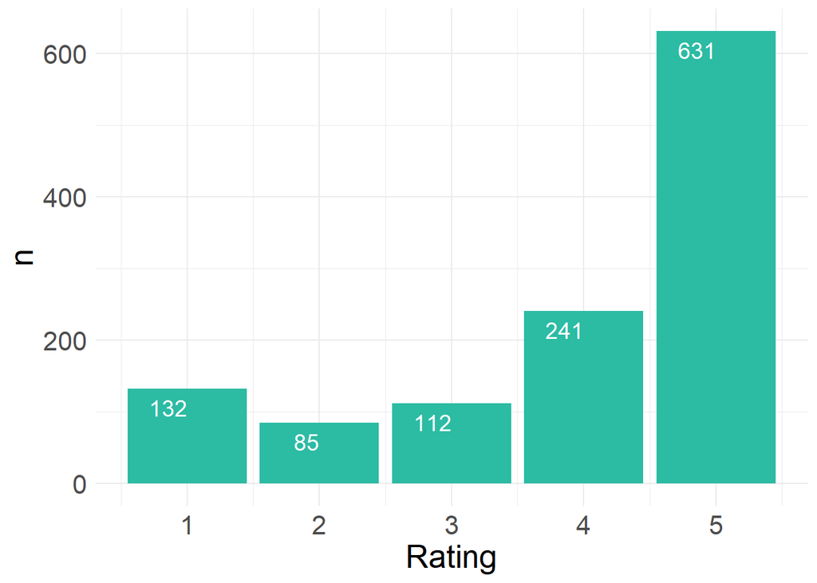

```r
ratingplot <- sample_df %>%
    count(Rating,sort=TRUE) %>%
    ggplot(aes(Rating, n)) +
    geom_col(fill="#2cbba3") +
    geom_text(aes(label=n), vjust=1.6, hjust=1, color="white", size= 5) +
    theme_minimal() +
    theme(text=element_text(size=20))

ratingplot
```

```r
# save  plot
ggsave("ratingplot.png", # the name of the file where it will be save
       plot = ratingplot, # what plot to save
       height=20, width=14, units="in")
```

#Tokenizing data

```r
# Tokenized review_text column by word
word_tokenized_data <-sample_df %>%
  unnest_tokens(output = word, input = "Review_text", token = "words", to_lower = TRUE)

# Tokenize review_text column by bigrams
bigram_tokenized_data<-sample_df %>%        unnest_tokens(output=bigram,input="Review_text",token="ngrams",n=2,to_lower=TRUE)
```

# Visualization using word plot(word)

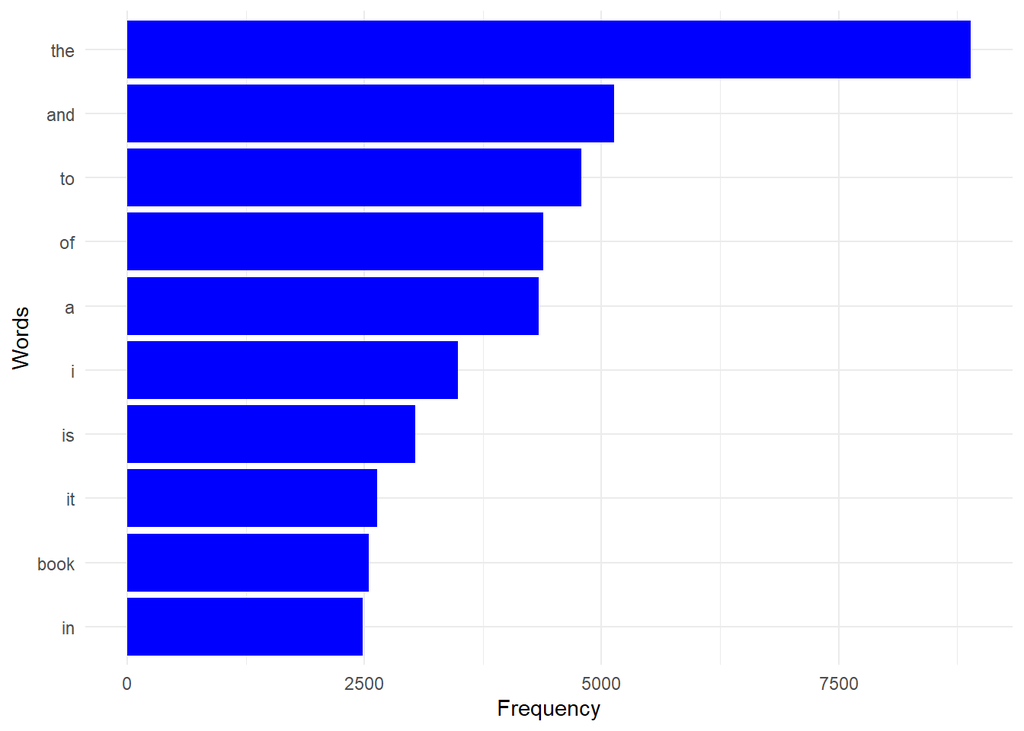

```r
word_counts <- word_tokenized_data %>%
  count(word, sort = TRUE) # Counts the occurrences of each word and sorts.

ggplot(word_counts[1:10, ], aes(x = reorder(word, n), y = n)) + # Plots first 10 rows of word counts, with word (ordered by n) on the x axis and n on the y axis
  geom_col(fill = "blue") + # Sets colors of bars to blue
  labs(x = "Words", y = "Frequency") + # Defines x and y labels
  coord_flip() + # Flips coordinates so words go on the y axis (for readability)
  theme_minimal() # Sets theme of visualization
```

Most common word is ‘the’.

# Visualization using word cloud

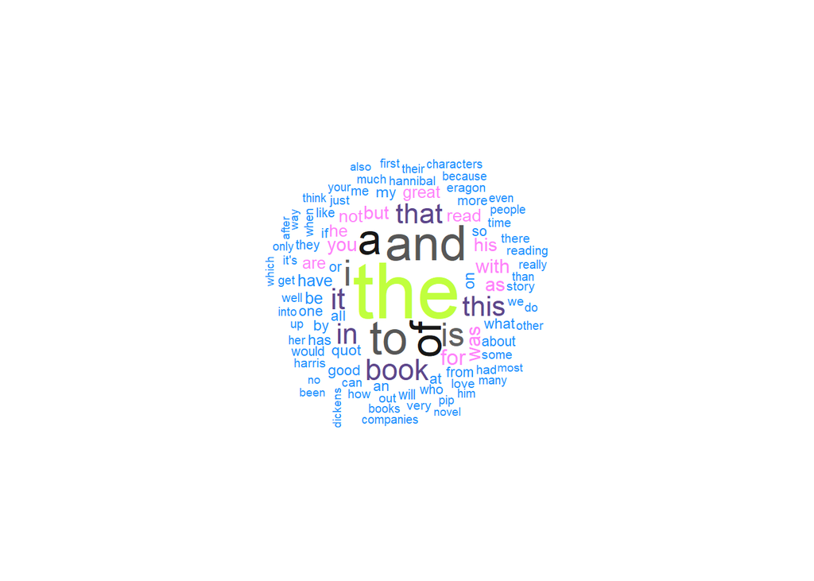

```r
set.seed(1)
wordcloud(words = word_counts$word,
          freq = word_counts$n,
          min.freq = 10,
          random.order=FALSE,
          random.color=FALSE,
          colors = sample(colors(), size = 10),
          max.words =100)
```

#visualization using pie chart

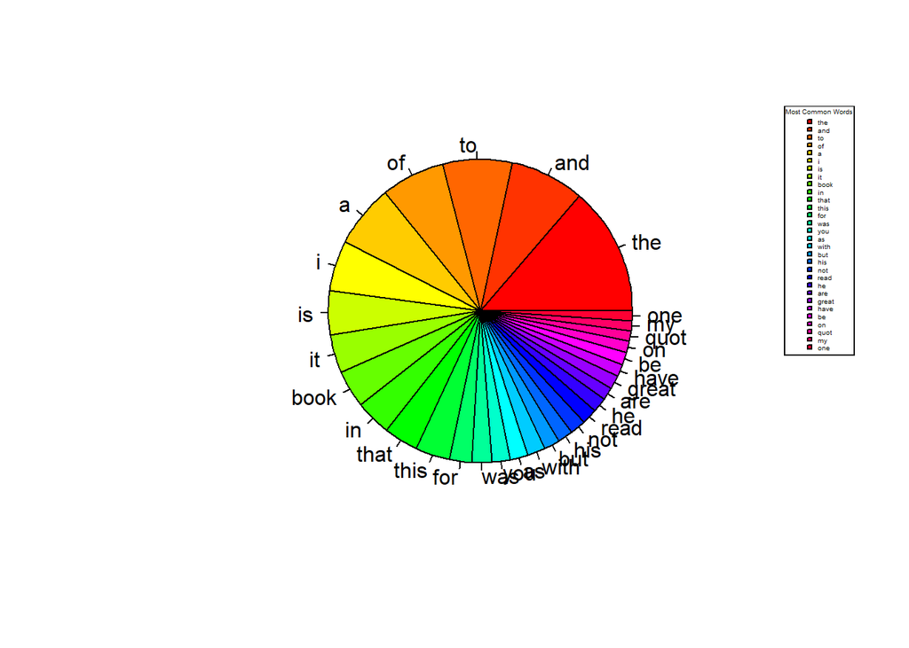

```r
word_counts <- word_tokenized_data %>%
  count(word, sort = TRUE)
# Limit to the top N most common words
top_n <- 30
word_counts <- head(word_counts, top_n)

# Plot a pie chart
pie(word_counts$n, labels = word_counts$word, col = rainbow(length(word_counts$n)))

# Add a legend with reduced font size
legend("topright",
  legend = word_counts$word,
  fill = rainbow(length(word_counts$n)),
  cex = 0.3,  # Adjust the font size (reduce as needed)
  title = "Most Common Words"
)
```

## For bigram

# visualization most common bigram using word plot(bigram)

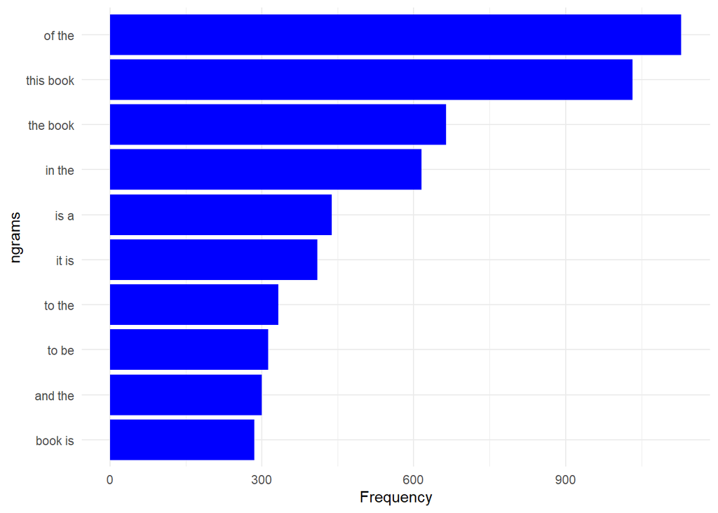

```r
word_counts <- bigram_tokenized_data %>%
  count(bigram, sort = TRUE) # Counts the accurrenc of each word and sorts.

ggplot(word_counts[1:10,], aes(x = reorder(bigram, n), y = n)) + # Plots first 10 rows of word counts, with word (ordered by n) on the x axis and n on the y axis
  geom_col(fill = "blue") + # Sets colors of bars to blue
  labs(x = "ngrams", y = "Frequency") + # Defines x and y labels
  coord_flip() + # Flips coordinates so words go on the y axis (for readability)
  theme_minimal() # Sets theme of visualization
```

#Data cleaning for words and bigrams

```r
clean_tokens <- word_tokenized_data %>%
  anti_join(stop_words, by = "word") # Removes stop words

# Remove special characters and numbers
clean_tokens$word <- gsub("[^a-zA-Z ]", "", clean_tokens$word) %>%
  na_if("") %>% # Replaces empty strings with NA
  lemmatize_words() # Lemmatizes text

clean_tokens <- na.omit(clean_tokens) # Removes null values

# Text can be untokenized and then retokenized to get cleaned bigrams
untokenized_data <- clean_tokens %>%
  group_by(Review_no) %>%
  summarize(clean_review = paste(word, collapse = " ")) %>% # for each review number, takes every word and joins them with spaces
  inner_join(df[, c("Title","Rating","Review_no","Review_title","Review_text", "Publisher", "First_author", "Genre")], by = "Review_no") # Joins cleaned reviews to original df

clean_bigrams <- untokenized_data %>%
  unnest_tokens(output = bigram, input = "clean_review", token = "ngrams", n=2, to_lower = TRUE) # Tokenize word column to bigrams
```

### After cleaning the data, visualize it using a word plot

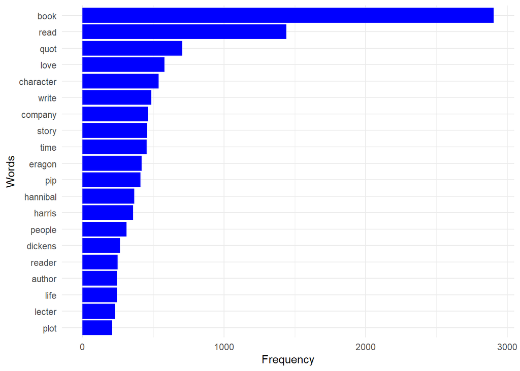

```r
word_counts <- clean_tokens %>%
  count(word, sort = TRUE)

top_words <- top_n(word_counts,20,n)$word

filtered_word_counts <- filter(word_counts, word %in% top_words)
filtered_word_counts$word <- factor(filtered_word_counts$word, levels = top_words[length(top_words):1])

ggplot(filtered_word_counts, aes(x = reorder(word, n), y = n)) +
  geom_col(fill = "blue") +
  labs(x = "Words", y = "Frequency") +
  coord_flip() +
  theme_minimal()
```

After cleaning the dataset,the most common word is ‘book’.